# **Predicting Popularity of Songs Based on Dancergy**

## Spring 2024 Data Science Project

Ethan Paritz, Alison Wang, Bill Zhou

Contribution: Ethan Paritz, Contribution: 100%

Alison Wang, Contribution: 100%

Bill Zhou, Contribution: 100%

We, all team members, agree together that the above information is true, and we are confident about our contributions to this submitted project/final tutorial

Ethan Paritz, Alison Wang, Bill Zhou

Ethan Paritz: Ethan contributed to all parts of the project. Specifically, he worked on data cleaning. Also, he focused on the box and whisker plot as well as the correlation heat map and scatterplot visualizations.

Alison Wang: Alison contributed to all parts of the project. Specifically she focused on the z-test hypothesis test in the initial analysis of the data. She also formatted the final tutorial report and uploaded it to github.

Bill Zhou: Bill contributed to all parts of the project. Specifically, he focused on explanations and graphing. He also did the statistical method of analyzing the dataset's distribution.

## **Introduction**

What makes one song popular and another song not as successful? The main purpose of this project is to analyze whether or not factors of the song impact the popularity. We decided to focus on dancergy, an element we made by combining danceability and energy. We wanted to see if it is possible to predict the popularity of a song based on its dancergy.  
Music producers have a goal, to spread their music for many people to enjoy. Therefore, they pay a lot of attention to what makes a song successful. Knowing which factors contribute to the popularity of the song allows them to focus on creating songs that feed into these factors. By analyzing the relationship between dancergy and popularity, we will be able to determine whether or not music producers should focus on dancergy to produce a popular song.

## **Data Curation**

Imports

```python
import pandas as pd
import seaborn as sns
import matplotlib.pyplot as plt
import numpy as np
import math
from statsmodels.stats.weightstats import ztest
from scipy.stats import norm
from sklearn.model_selection import train_test_split
from sklearn.linear_model import LinearRegression
from sklearn.metrics import mean_squared_error, r2_score
# Uploaded Tracks, Million Songs, and User Behavior Data
```

```python
# Mount Drive and determine working directory
from google.colab import drive
drive.mount('/content/drive')
%cd "/content/drive/MyDrive/cmsc320 Group/"
```

```
/content/drive/.shortcut-targets-by-id/1BVAVjTxLUZ8aTnKnJxGGEv-byndlPLo0/cmsc320 Group
```

Uploading csv file

```python
tracks = pd.read_csv("dataset.csv")
tracks.head()
```

|  | Unnamed: 0 | track_id | artists | album_name | track_name | popularity | duration_ms | explicit | danceability | energy | ... | loudness | mode | speechiness | acousticness | instrumentalness | liveness | valence | tempo | time_signature | track_genre |
| --- | --- | --- | --- | --- | --- | --- | --- | --- | --- | --- | --- | --- | --- | --- | --- | --- | --- | --- | --- | --- | --- |
| 0 | 0 | 5SuOikwiRyPMVoIQDJUgSV | Gen Hoshino | Comedy | Comedy | 73 | 230666 | False | 0.676 | 0.4610 | ... | -6.746 | 0 | 0.1430 | 0.0322 | 0.000001 | 0.3580 | 0.715 | 87.917 | 4 | acoustic |
| 1 | 1 | 4qPNDBW1i3p13qLCt0Ki3A | Ben Woodward | Ghost (Acoustic) | Ghost - Acoustic | 55 | 149610 | False | 0.420 | 0.1660 | ... | -17.235 | 1 | 0.0763 | 0.9240 | 0.000006 | 0.1010 | 0.267 | 77.489 | 4 | acoustic |
| 2 | 2 | 1iJBSr7s7jYXzM8EGcbK5b | Ingrid Michaelson;ZAYN | To Begin Again | To Begin Again | 57 | 210826 | False | 0.438 | 0.3590 | ... | -9.734 | 1 | 0.0557 | 0.2100 | 0.000000 | 0.1170 | 0.120 | 76.332 | 4 | acoustic |
| 3 | 3 | 6lfxq3CG4xtTiEg7opyCyx | Kina Grannis | Crazy Rich Asians (Original Motion Picture Sou... | Can't Help Falling In Love | 71 | 201933 | False | 0.266 | 0.0596 | ... | -18.515 | 1 | 0.0363 | 0.9050 | 0.000071 | 0.1320 | 0.143 | 181.740 | 3 | acoustic |
| 4 | 4 | 5vjLSffimiIP26QG5WcN2K | Chord Overstreet | Hold On | Hold On | 82 | 198853 | False | 0.618 | 0.4430 | ... | -9.681 | 1 | 0.0526 | 0.4690 | 0.000000 | 0.0829 | 0.167 | 119.949 | 4 | acoustic |

5 rows × 21 columns

## Data Processing

Gather basic shape

```python
init_shape = tracks.shape[0]
tracks.dtypes
```

```
Unnamed: 0            int64
track_id             object
artists              object
album_name           object
track_name           object
popularity            int64
duration_ms           int64
explicit               bool
danceability        float64
energy              float64
key                   int64
loudness            float64
mode                  int64
speechiness         float64
acousticness        float64
instrumentalness    float64
liveness            float64
valence             float64
tempo               float64
time_signature        int64
track_genre          object
dtype: object
```

Drop Rows with Null in Them

```python
tracks = tracks.dropna()
tracks.isnull().sum()
```

```
Unnamed: 0          0
track_id            0
artists             0
album_name          0
track_name          0
popularity          0
duration_ms         0
explicit            0
danceability        0
energy              0
key                 0
loudness            0
mode                0
speechiness         0
acousticness        0
instrumentalness    0
liveness            0
valence             0
tempo               0
time_signature      0
track_genre         0
dtype: int64
```

Gets rid of duplicates

```python
duplicate_count = tracks.duplicated()
# duplicate_count.value_counts() # No Duplicates
```

Filters by getting songs with atleast some music (not just spoken words) and only valid time signatures

```python
tracks = tracks[tracks["time_signature"] >= 3]
tracks = tracks[tracks["time_signature"] <= 7]
tracks = tracks[tracks["speechiness"] <= .66]
tracks
```

|  | Unnamed: 0 | track_id | artists | album_name | track_name | popularity | duration_ms | explicit | danceability | energy | ... | loudness | mode | speechiness | acousticness | instrumentalness | liveness | valence | tempo | time_signature | track_genre |
| --- | --- | --- | --- | --- | --- | --- | --- | --- | --- | --- | --- | --- | --- | --- | --- | --- | --- | --- | --- | --- | --- |
| 0 | 0 | 5SuOikwiRyPMVoIQDJUgSV | Gen Hoshino | Comedy | Comedy | 73 | 230666 | False | 0.676 | 0.4610 | ... | -6.746 | 0 | 0.1430 | 0.0322 | 0.000001 | 0.3580 | 0.7150 | 87.917 | 4 | acoustic |
| 1 | 1 | 4qPNDBW1i3p13qLCt0Ki3A | Ben Woodward | Ghost (Acoustic) | Ghost - Acoustic | 55 | 149610 | False | 0.420 | 0.1660 | ... | -17.235 | 1 | 0.0763 | 0.9240 | 0.000006 | 0.1010 | 0.2670 | 77.489 | 4 | acoustic |
| 2 | 2 | 1iJBSr7s7jYXzM8EGcbK5b | Ingrid Michaelson;ZAYN | To Begin Again | To Begin Again | 57 | 210826 | False | 0.438 | 0.3590 | ... | -9.734 | 1 | 0.0557 | 0.2100 | 0.000000 | 0.1170 | 0.1200 | 76.332 | 4 | acoustic |
| 3 | 3 | 6lfxq3CG4xtTiEg7opyCyx | Kina Grannis | Crazy Rich Asians (Original Motion Picture Sou... | Can't Help Falling In Love | 71 | 201933 | False | 0.266 | 0.0596 | ... | -18.515 | 1 | 0.0363 | 0.9050 | 0.000071 | 0.1320 | 0.1430 | 181.740 | 3 | acoustic |
| 4 | 4 | 5vjLSffimiIP26QG5WcN2K | Chord Overstreet | Hold On | Hold On | 82 | 198853 | False | 0.618 | 0.4430 | ... | -9.681 | 1 | 0.0526 | 0.4690 | 0.000000 | 0.0829 | 0.1670 | 119.949 | 4 | acoustic |
| ... | ... | ... | ... | ... | ... | ... | ... | ... | ... | ... | ... | ... | ... | ... | ... | ... | ... | ... | ... | ... | ... |
| 113995 | 113995 | 2C3TZjDRiAzdyViavDJ217 | Rainy Lullaby | #mindfulness - Soft Rain for Mindful Meditatio... | Sleep My Little Boy | 21 | 384999 | False | 0.172 | 0.2350 | ... | -16.393 | 1 | 0.0422 | 0.6400 | 0.928000 | 0.0863 | 0.0339 | 125.995 | 5 | world-music |
| 113996 | 113996 | 1hIz5L4IB9hN3WRYPOCGPw | Rainy Lullaby | #mindfulness - Soft Rain for Mindful Meditatio... | Water Into Light | 22 | 385000 | False | 0.174 | 0.1170 | ... | -18.318 | 0 | 0.0401 | 0.9940 | 0.976000 | 0.1050 | 0.0350 | 85.239 | 4 | world-music |
| 113997 | 113997 | 6x8ZfSoqDjuNa5SVP5QjvX | Cesária Evora | Best Of | Miss Perfumado | 22 | 271466 | False | 0.629 | 0.3290 | ... | -10.895 | 0 | 0.0420 | 0.8670 | 0.000000 | 0.0839 | 0.7430 | 132.378 | 4 | world-music |
| 113998 | 113998 | 2e6sXL2bYv4bSz6VTdnfLs | Michael W. Smith | Change Your World | Friends | 41 | 283893 | False | 0.587 | 0.5060 | ... | -10.889 | 1 | 0.0297 | 0.3810 | 0.000000 | 0.2700 | 0.4130 | 135.960 | 4 | world-music |
| 113999 | 113999 | 2hETkH7cOfqmz3LqZDHZf5 | Cesária Evora | Miss Perfumado | Barbincor | 22 | 241826 | False | 0.526 | 0.4870 | ... | -10.204 | 0 | 0.0725 | 0.6810 | 0.000000 | 0.0893 | 0.7080 | 79.198 | 4 | world-music |

112040 rows × 21 columns

Better organizes the data, dropping useless columns and renaming others

```python
tracks = tracks.drop(columns=["album_name", "track_id", "artists", "track_name", "key", "mode", "Unnamed: 0", "time_signature"])
tracks = tracks.rename(columns={"track_genre":"genre"})
tracks.head()
```

|  | popularity | duration_ms | explicit | danceability | energy | loudness | speechiness | acousticness | instrumentalness | liveness | valence | tempo | genre |
| --- | --- | --- | --- | --- | --- | --- | --- | --- | --- | --- | --- | --- | --- |
| 0 | 73 | 230666 | False | 0.676 | 0.4610 | -6.746 | 0.1430 | 0.0322 | 0.000001 | 0.3580 | 0.715 | 87.917 | acoustic |
| 1 | 55 | 149610 | False | 0.420 | 0.1660 | -17.235 | 0.0763 | 0.9240 | 0.000006 | 0.1010 | 0.267 | 77.489 | acoustic |
| 2 | 57 | 210826 | False | 0.438 | 0.3590 | -9.734 | 0.0557 | 0.2100 | 0.000000 | 0.1170 | 0.120 | 76.332 | acoustic |
| 3 | 71 | 201933 | False | 0.266 | 0.0596 | -18.515 | 0.0363 | 0.9050 | 0.000071 | 0.1320 | 0.143 | 181.740 | acoustic |
| 4 | 82 | 198853 | False | 0.618 | 0.4430 | -9.681 | 0.0526 | 0.4690 | 0.000000 | 0.0829 | 0.167 | 119.949 | acoustic |

Summary Statistics

```python
tracks.describe()
```

|  | popularity | duration_ms | danceability | energy | loudness | speechiness | acousticness | instrumentalness | liveness | valence | tempo |
| --- | --- | --- | --- | --- | --- | --- | --- | --- | --- | --- | --- |
| count | 112040.000000 | 1.120400e+05 | 112040.000000 | 112040.000000 | 112040.000000 | 112040.000000 | 112040.000000 | 112040.000000 | 112040.000000 | 112040.000000 | 112040.000000 |
| mean | 33.338138 | 2.282750e+05 | 0.568862 | 0.643264 | -8.177751 | 0.078404 | 0.308939 | 0.155139 | 0.209332 | 0.476325 | 122.602054 |
| std | 22.390435 | 1.056602e+05 | 0.172223 | 0.249941 | 4.937789 | 0.077372 | 0.329488 | 0.308451 | 0.184422 | 0.258933 | 29.562831 |
| min | 0.000000 | 1.580000e+04 | 0.051300 | 0.000020 | -46.591000 | 0.022100 | 0.000000 | 0.000000 | 0.009250 | 0.000000 | 30.200000 |
| 25% | 17.000000 | 1.748000e+05 | 0.457000 | 0.475000 | -9.917000 | 0.035800 | 0.016400 | 0.000000 | 0.097600 | 0.262000 | 99.930000 |
| 50% | 35.000000 | 2.131625e+05 | 0.582000 | 0.686000 | -6.961000 | 0.048700 | 0.162000 | 0.000044 | 0.131000 | 0.466000 | 122.299500 |
| 75% | 50.000000 | 2.614922e+05 | 0.696000 | 0.854000 | -4.980000 | 0.083000 | 0.581000 | 0.048200 | 0.269000 | 0.685000 | 140.160500 |
| max | 100.000000 | 5.237295e+06 | 0.985000 | 1.000000 | 4.532000 | 0.660000 | 0.996000 | 1.000000 | 1.000000 | 0.995000 | 243.372000 |

Gets the change in rows from the beginning of processing to this point

```python
final_shape = tracks.shape[0]
print("Change in Size is " + str(init_shape - final_shape))
```

```
Change in Size is 1960
```

## **Exploratory Data Analysis**

In this step, we begin to format the data in a manner that allows us to perform analysis more easily later. In this section, we will add a new column called dancergy, begin simplifying the dataset by getting rid of unnecessary columns, and much more. We then perform 3 statistical methods that help us better understand the data.

Adds a new variable dancergy

Dancergy is dervied from square rooting the product of danceability and energy

$\sqrt{danceability * energy}$

```python
tracks["dancergy"] = pow((tracks["danceability"] * tracks["energy"]), .5)
tracks.head()
```

|  | popularity | duration_ms | explicit | danceability | energy | loudness | speechiness | acousticness | instrumentalness | liveness | valence | tempo | genre | dancergy |
| --- | --- | --- | --- | --- | --- | --- | --- | --- | --- | --- | --- | --- | --- | --- |
| 0 | 73 | 230666 | False | 0.676 | 0.4610 | -6.746 | 0.1430 | 0.0322 | 0.000001 | 0.3580 | 0.715 | 87.917 | acoustic | 0.558244 |
| 1 | 55 | 149610 | False | 0.420 | 0.1660 | -17.235 | 0.0763 | 0.9240 | 0.000006 | 0.1010 | 0.267 | 77.489 | acoustic | 0.264045 |
| 2 | 57 | 210826 | False | 0.438 | 0.3590 | -9.734 | 0.0557 | 0.2100 | 0.000000 | 0.1170 | 0.120 | 76.332 | acoustic | 0.396538 |
| 3 | 71 | 201933 | False | 0.266 | 0.0596 | -18.515 | 0.0363 | 0.9050 | 0.000071 | 0.1320 | 0.143 | 181.740 | acoustic | 0.125911 |
| 4 | 82 | 198853 | False | 0.618 | 0.4430 | -9.681 | 0.0526 | 0.4690 | 0.000000 | 0.0829 | 0.167 | 119.949 | acoustic | 0.523234 |

We will primarily be focused on examining the relationship between dancergy (danceability and energy) and popularity.

### Box and Whisker Plot

Creates box and whisker plots for each numerical column, in order to find the outliers

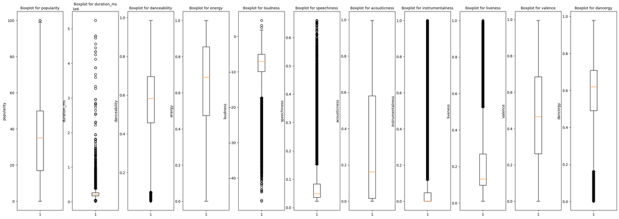

```python
categories = ["popularity", "duration_ms", "danceability", "energy", "loudness", "speechiness", "acousticness", "instrumentalness", "liveness", "valence", "dancergy"]
fig, ax1 = plt.subplots(1, len(categories), figsize = (30, 10))
count = 0
for category in categories:
  ax1[count].boxplot(tracks[category])
  ax1[count].set_title("Boxplot for " + category)
  ax1[count].title.set_size(10)
  ax1[count].set_ylabel(category)
  count = count + 1
```

### Outliers

Finds the amount of outliers in each category

```python
# Find Outliers
outlier_lists = []
for category in categories:
  q1 = tracks[category].quantile(.25)
  q3 = tracks[category].quantile(.75)
  iqr = q3 - q1
  outliers1 = tracks[tracks[category] > (q3+1.5*iqr)]
  outliers = pd.concat((outliers1, tracks[tracks[category] < (q1-1.5*iqr)]))
  outlier_lists.append(outliers)
  print(category + " has " + str(outliers.shape[0]) + " outliers")
```

```
popularity has 2 outliers
duration_ms has 5543 outliers
danceability has 460 outliers
energy has 0 outliers
loudness has 5931 outliers
speechiness has 12619 outliers
acousticness has 0 outliers
instrumentalness has 24777 outliers
liveness has 7972 outliers
valence has 0 outliers
dancergy has 2811 outliers
```

Prints out a dataframe with every outlier in each category

```python
for elem in range (0, len(outlier_lists)):
  if not (outlier_lists[elem].shape[0] == 0):
    print("\n\n\n" + categories[elem] + " outliers")
    display(outlier_lists[elem])
```

```
popularity outliers
```

|  | popularity | duration_ms | explicit | danceability | energy | loudness | speechiness | acousticness | instrumentalness | liveness | valence | tempo | genre | dancergy |
| --- | --- | --- | --- | --- | --- | --- | --- | --- | --- | --- | --- | --- | --- | --- |
| 20001 | 100 | 156943 | False | 0.714 | 0.472 | -7.375 | 0.0864 | 0.013 | 0.000005 | 0.266 | 0.238 | 131.121 | dance | 0.580524 |
| 81051 | 100 | 156943 | False | 0.714 | 0.472 | -7.375 | 0.0864 | 0.013 | 0.000005 | 0.266 | 0.238 | 131.121 | pop | 0.580524 |

```
duration_ms outliers
```

|  | popularity | duration_ms | explicit | danceability | energy | loudness | speechiness | acousticness | instrumentalness | liveness | valence | tempo | genre | dancergy |
| --- | --- | --- | --- | --- | --- | --- | --- | --- | --- | --- | --- | --- | --- | --- |
| 253 | 44 | 447306 | False | 0.588 | 0.6040 | -7.602 | 0.0240 | 0.3430 | 0.000069 | 0.2520 | 0.351 | 92.020 | acoustic | 0.595946 |
| 650 | 52 | 406103 | False | 0.592 | 0.0833 | -16.517 | 0.0835 | 0.9460 | 0.079100 | 0.0941 | 0.205 | 143.243 | acoustic | 0.222067 |
| 752 | 52 | 445533 | False | 0.639 | 0.4960 | -6.844 | 0.0375 | 0.7130 | 0.254000 | 0.0545 | 0.467 | 140.394 | acoustic | 0.562978 |
| 851 | 33 | 578064 | False | 0.685 | 0.4830 | -9.082 | 0.0253 | 0.0772 | 0.000061 | 0.1130 | 0.331 | 93.032 | acoustic | 0.575200 |
| 896 | 26 | 403911 | True | 0.335 | 0.6960 | -9.472 | 0.0307 | 0.6420 | 0.000000 | 0.1200 | 0.403 | 95.240 | acoustic | 0.482866 |
| ... | ... | ... | ... | ... | ... | ... | ... | ... | ... | ... | ... | ... | ... | ... |
| 110931 | 22 | 30474 | False | 0.776 | 0.7550 | -9.867 | 0.0668 | 0.0290 | 0.000123 | 0.6500 | 0.853 | 126.011 | trance | 0.765428 |
| 110934 | 22 | 37533 | False | 0.852 | 0.6840 | -12.282 | 0.3490 | 0.0124 | 0.000000 | 0.1220 | 0.480 | 125.930 | trance | 0.763392 |
| 110935 | 23 | 30474 | False | 0.500 | 0.9220 | -6.575 | 0.1070 | 0.0389 | 0.000033 | 0.5550 | 0.715 | 126.027 | trance | 0.678970 |
| 111582 | 19 | 42333 | False | 0.567 | 0.7390 | -11.632 | 0.0658 | 0.0231 | 0.908000 | 0.1340 | 0.762 | 165.968 | trip-hop | 0.647312 |
| 111735 | 48 | 37626 | False | 0.497 | 0.4100 | -23.330 | 0.5330 | 0.7740 | 0.000965 | 0.1280 | 0.965 | 52.581 | trip-hop | 0.451409 |

5543 rows × 14 columns

```
danceability outliers
```

|  | popularity | duration_ms | explicit | danceability | energy | loudness | speechiness | acousticness | instrumentalness | liveness | valence | tempo | genre | dancergy |
| --- | --- | --- | --- | --- | --- | --- | --- | --- | --- | --- | --- | --- | --- | --- |
| 4077 | 65 | 371746 | False | 0.0650 | 0.34100 | -12.743 | 0.0482 | 0.154 | 0.854000 | 0.1090 | 0.0334 | 65.380 | ambient | 0.148879 |
| 4090 | 1 | 378378 | False | 0.0819 | 0.01320 | -25.217 | 0.0494 | 0.964 | 0.647000 | 0.1200 | 0.0320 | 82.637 | ambient | 0.032880 |
| 4097 | 0 | 464453 | False | 0.0713 | 0.00696 | -39.507 | 0.0405 | 0.994 | 0.915000 | 0.0710 | 0.0977 | 213.848 | ambient | 0.022277 |
| 4183 | 67 | 486840 | False | 0.0783 | 0.20600 | -20.611 | 0.0337 | 0.864 | 0.838000 | 0.1790 | 0.0807 | 80.341 | ambient | 0.127003 |
| 4191 | 0 | 201651 | False | 0.0877 | 0.04520 | -22.712 | 0.0431 | 0.988 | 0.936000 | 0.1090 | 0.0353 | 85.425 | ambient | 0.062961 |
| ... | ... | ... | ... | ... | ... | ... | ... | ... | ... | ... | ... | ... | ... | ... |
| 113839 | 23 | 324999 | False | 0.0688 | 0.04340 | -23.135 | 0.0407 | 0.981 | 0.868000 | 0.1040 | 0.0380 | 70.747 | world-music | 0.054644 |
| 113899 | 22 | 371000 | False | 0.0880 | 0.12300 | -21.381 | 0.0428 | 0.990 | 0.869000 | 0.0787 | 0.0342 | 70.189 | world-music | 0.104038 |
| 113912 | 21 | 278726 | False | 0.0903 | 0.00895 | -31.771 | 0.0394 | 0.951 | 0.977000 | 0.0942 | 0.0348 | 79.452 | world-music | 0.028429 |
| 113940 | 22 | 289999 | False | 0.0565 | 0.99500 | -21.042 | 0.3520 | 0.867 | 0.000419 | 0.6830 | 0.0101 | 53.465 | world-music | 0.237102 |
| 113977 | 21 | 290999 | False | 0.0672 | 0.09030 | -23.496 | 0.0401 | 0.970 | 0.977000 | 0.0930 | 0.0361 | 76.042 | world-music | 0.077898 |

460 rows × 14 columns

```
loudness outliers
```

|  | popularity | duration_ms | explicit | danceability | energy | loudness | speechiness | acousticness | instrumentalness | liveness | valence | tempo | genre | dancergy |
| --- | --- | --- | --- | --- | --- | --- | --- | --- | --- | --- | --- | --- | --- | --- |
| 17574 | 16 | 237000 | False | 0.3100 | 0.9990 | 4.532 | 0.3430 | 0.000102 | 0.945000 | 0.148 | 0.0333 | 160.040 | club | 0.556498 |
| 38840 | 25 | 176065 | False | 0.4420 | 0.8000 | 2.574 | 0.0686 | 0.262000 | 0.000001 | 0.664 | 0.3690 | 118.053 | garage | 0.594643 |
| 59225 | 0 | 60056 | False | 0.1490 | 0.8680 | 3.156 | 0.0767 | 0.191000 | 0.865000 | 0.625 | 0.0494 | 136.188 | iranian | 0.359628 |
| 3 | 71 | 201933 | False | 0.2660 | 0.0596 | -18.515 | 0.0363 | 0.905000 | 0.000071 | 0.132 | 0.1430 | 181.740 | acoustic | 0.125911 |
| 16 | 56 | 129750 | False | 0.7060 | 0.1120 | -18.098 | 0.0391 | 0.827000 | 0.000004 | 0.125 | 0.4140 | 110.154 | acoustic | 0.281197 |
| ... | ... | ... | ... | ... | ... | ... | ... | ... | ... | ... | ... | ... | ... | ... |
| 113972 | 21 | 170387 | False | 0.1700 | 0.0520 | -28.693 | 0.0374 | 0.875000 | 0.904000 | 0.129 | 0.0475 | 114.573 | world-music | 0.094021 |
| 113977 | 21 | 290999 | False | 0.0672 | 0.0903 | -23.496 | 0.0401 | 0.970000 | 0.977000 | 0.093 | 0.0361 | 76.042 | world-music | 0.077898 |
| 113979 | 22 | 143403 | False | 0.4170 | 0.9670 | -27.146 | 0.0503 | 0.924000 | 0.958000 | 0.696 | 0.0147 | 65.002 | world-music | 0.635011 |
| 113986 | 21 | 335999 | False | 0.1980 | 0.2570 | -17.361 | 0.0415 | 0.968000 | 0.949000 | 0.110 | 0.0381 | 89.494 | world-music | 0.225579 |
| 113996 | 22 | 385000 | False | 0.1740 | 0.1170 | -18.318 | 0.0401 | 0.994000 | 0.976000 | 0.105 | 0.0350 | 85.239 | world-music | 0.142681 |

5931 rows × 14 columns

```
speechiness outliers
```

|  | popularity | duration_ms | explicit | danceability | energy | loudness | speechiness | acousticness | instrumentalness | liveness | valence | tempo | genre | dancergy |
| --- | --- | --- | --- | --- | --- | --- | --- | --- | --- | --- | --- | --- | --- | --- |
| 370 | 38 | 211672 | False | 0.6720 | 0.644 | -9.063 | 0.236 | 0.79500 | 0.000000 | 0.146 | 0.5490 | 148.135 | acoustic | 0.657851 |
| 692 | 28 | 204926 | False | 0.5440 | 0.911 | -2.730 | 0.204 | 0.66100 | 0.000000 | 0.344 | 0.8510 | 114.776 | acoustic | 0.703977 |
| 713 | 30 | 201506 | False | 0.8040 | 0.457 | -7.845 | 0.197 | 0.60000 | 0.000000 | 0.150 | 0.5520 | 98.035 | acoustic | 0.606158 |
| 768 | 46 | 183337 | False | 0.8020 | 0.183 | -17.100 | 0.403 | 0.80900 | 0.000000 | 0.109 | 0.6640 | 91.078 | acoustic | 0.383101 |
| 815 | 45 | 145753 | False | 0.4630 | 0.156 | -13.416 | 0.189 | 0.89000 | 0.000000 | 0.115 | 0.4780 | 180.191 | acoustic | 0.268753 |
| ... | ... | ... | ... | ... | ... | ... | ... | ... | ... | ... | ... | ... | ... | ... |
| 113302 | 52 | 173500 | False | 0.6950 | 0.568 | -8.636 | 0.170 | 0.06840 | 0.000007 | 0.307 | 0.3420 | 99.997 | world-music | 0.628299 |
| 113818 | 43 | 195516 | False | 0.3480 | 0.693 | -6.024 | 0.187 | 0.20800 | 0.000000 | 0.268 | 0.2450 | 87.969 | world-music | 0.491085 |
| 113923 | 47 | 209608 | False | 0.4450 | 0.593 | -7.496 | 0.160 | 0.06570 | 0.000051 | 0.297 | 0.3260 | 171.774 | world-music | 0.513697 |
| 113940 | 22 | 289999 | False | 0.0565 | 0.995 | -21.042 | 0.352 | 0.86700 | 0.000419 | 0.683 | 0.0101 | 53.465 | world-music | 0.237102 |
| 113981 | 39 | 289179 | False | 0.4980 | 0.957 | -5.807 | 0.162 | 0.00527 | 0.000000 | 0.477 | 0.2050 | 128.028 | world-music | 0.690352 |

12619 rows × 14 columns

```
instrumentalness outliers
```

|  | popularity | duration_ms | explicit | danceability | energy | loudness | speechiness | acousticness | instrumentalness | liveness | valence | tempo | genre | dancergy |
| --- | --- | --- | --- | --- | --- | --- | --- | --- | --- | --- | --- | --- | --- | --- |
| 56 | 51 | 234473 | False | 0.526 | 0.3330 | -13.020 | 0.0314 | 0.910 | 0.168 | 0.1110 | 0.1590 | 94.951 | acoustic | 0.418519 |
| 62 | 66 | 124933 | False | 0.616 | 0.2820 | -15.317 | 0.0331 | 0.983 | 0.833 | 0.1300 | 0.4350 | 96.638 | acoustic | 0.416788 |
| 72 | 57 | 354400 | False | 0.541 | 0.5750 | -9.463 | 0.0491 | 0.677 | 0.215 | 0.1020 | 0.4280 | 91.980 | acoustic | 0.557741 |
| 77 | 45 | 330933 | False | 0.537 | 0.3420 | -13.553 | 0.0273 | 0.645 | 0.266 | 0.0687 | 0.2530 | 109.236 | acoustic | 0.428549 |
| 116 | 47 | 112008 | False | 0.565 | 0.0392 | -28.276 | 0.0450 | 0.835 | 0.183 | 0.1170 | 0.6010 | 125.399 | acoustic | 0.148822 |
| ... | ... | ... | ... | ... | ... | ... | ... | ... | ... | ... | ... | ... | ... | ... |
| 113979 | 22 | 143403 | False | 0.417 | 0.9670 | -27.146 | 0.0503 | 0.924 | 0.958 | 0.6960 | 0.0147 | 65.002 | world-music | 0.635011 |
| 113986 | 21 | 335999 | False | 0.198 | 0.2570 | -17.361 | 0.0415 | 0.968 | 0.949 | 0.1100 | 0.0381 | 89.494 | world-music | 0.225579 |
| 113990 | 22 | 369049 | False | 0.579 | 0.2450 | -16.357 | 0.0384 | 0.970 | 0.924 | 0.1010 | 0.3020 | 112.011 | world-music | 0.376636 |
| 113995 | 21 | 384999 | False | 0.172 | 0.2350 | -16.393 | 0.0422 | 0.640 | 0.928 | 0.0863 | 0.0339 | 125.995 | world-music | 0.201047 |
| 113996 | 22 | 385000 | False | 0.174 | 0.1170 | -18.318 | 0.0401 | 0.994 | 0.976 | 0.1050 | 0.0350 | 85.239 | world-music | 0.142681 |

24777 rows × 14 columns

```
liveness outliers
```

|  | popularity | duration_ms | explicit | danceability | energy | loudness | speechiness | acousticness | instrumentalness | liveness | valence | tempo | genre | dancergy |
| --- | --- | --- | --- | --- | --- | --- | --- | --- | --- | --- | --- | --- | --- | --- |
| 51 | 61 | 232360 | False | 0.373 | 0.914 | -4.185 | 0.0565 | 0.07600 | 0.000000 | 0.669 | 0.5600 | 168.210 | acoustic | 0.583885 |
| 73 | 56 | 177500 | False | 0.607 | 0.473 | -8.555 | 0.0340 | 0.71200 | 0.000000 | 0.660 | 0.5400 | 119.698 | acoustic | 0.535827 |
| 343 | 34 | 192392 | False | 0.415 | 0.619 | -7.624 | 0.1230 | 0.94600 | 0.000028 | 0.799 | 0.7390 | 77.009 | acoustic | 0.506838 |
| 518 | 45 | 262954 | False | 0.407 | 0.357 | -11.659 | 0.0436 | 0.77500 | 0.001050 | 0.940 | 0.2530 | 112.207 | acoustic | 0.381181 |
| 535 | 60 | 188200 | False | 0.745 | 0.436 | -9.617 | 0.0430 | 0.59700 | 0.021300 | 0.610 | 0.7710 | 114.216 | acoustic | 0.569930 |
| ... | ... | ... | ... | ... | ... | ... | ... | ... | ... | ... | ... | ... | ... | ... |
| 113967 | 46 | 332604 | False | 0.392 | 0.668 | -7.342 | 0.0296 | 0.00356 | 0.000560 | 0.588 | 0.1150 | 148.013 | world-music | 0.511719 |
| 113973 | 44 | 260839 | False | 0.319 | 0.577 | -7.679 | 0.0330 | 0.04990 | 0.000000 | 0.729 | 0.1890 | 97.678 | world-music | 0.429026 |
| 113979 | 22 | 143403 | False | 0.417 | 0.967 | -27.146 | 0.0503 | 0.92400 | 0.958000 | 0.696 | 0.0147 | 65.002 | world-music | 0.635011 |
| 113983 | 37 | 377697 | False | 0.363 | 0.462 | -8.232 | 0.0284 | 0.00887 | 0.000009 | 0.706 | 0.0687 | 80.003 | world-music | 0.409519 |
| 113989 | 22 | 380344 | False | 0.495 | 0.281 | -12.070 | 0.0316 | 0.39200 | 0.000000 | 0.662 | 0.2060 | 127.731 | world-music | 0.372954 |

7972 rows × 14 columns

```
dancergy outliers
```

|  | popularity | duration_ms | explicit | danceability | energy | loudness | speechiness | acousticness | instrumentalness | liveness | valence | tempo | genre | dancergy |
| --- | --- | --- | --- | --- | --- | --- | --- | --- | --- | --- | --- | --- | --- | --- |
| 3 | 71 | 201933 | False | 0.2660 | 0.0596 | -18.515 | 0.0363 | 0.905 | 0.000071 | 0.132 | 0.1430 | 181.740 | acoustic | 0.125911 |
| 116 | 47 | 112008 | False | 0.5650 | 0.0392 | -28.276 | 0.0450 | 0.835 | 0.183000 | 0.117 | 0.6010 | 125.399 | acoustic | 0.148822 |
| 279 | 54 | 211624 | False | 0.2710 | 0.0937 | -15.035 | 0.0367 | 0.939 | 0.000000 | 0.108 | 0.1470 | 164.721 | acoustic | 0.159351 |
| 283 | 51 | 137066 | False | 0.4860 | 0.0399 | -21.560 | 0.0405 | 0.953 | 0.000009 | 0.115 | 0.1550 | 95.066 | acoustic | 0.139253 |
| 353 | 55 | 144653 | False | 0.4400 | 0.0353 | -20.858 | 0.0522 | 0.990 | 0.003120 | 0.108 | 0.3620 | 181.988 | acoustic | 0.124627 |
| ... | ... | ... | ... | ... | ... | ... | ... | ... | ... | ... | ... | ... | ... | ... |
| 113965 | 21 | 125580 | False | 0.2100 | 0.0712 | -26.100 | 0.0518 | 0.501 | 0.922000 | 0.111 | 0.0387 | 62.201 | world-music | 0.122278 |
| 113971 | 21 | 359003 | False | 0.3120 | 0.0330 | -25.894 | 0.0307 | 0.853 | 0.851000 | 0.114 | 0.0639 | 79.655 | world-music | 0.101469 |
| 113972 | 21 | 170387 | False | 0.1700 | 0.0520 | -28.693 | 0.0374 | 0.875 | 0.904000 | 0.129 | 0.0475 | 114.573 | world-music | 0.094021 |
| 113977 | 21 | 290999 | False | 0.0672 | 0.0903 | -23.496 | 0.0401 | 0.970 | 0.977000 | 0.093 | 0.0361 | 76.042 | world-music | 0.077898 |
| 113996 | 22 | 385000 | False | 0.1740 | 0.1170 | -18.318 | 0.0401 | 0.994 | 0.976000 | 0.105 | 0.0350 | 85.239 | world-music | 0.142681 |

2811 rows × 14 columns

We learned that there several outliers for popularity, duration, danceability, loudness, speechiness, instrumentalness, liveness, and dancergy.

Out of 112040 songs, dancergy has 2811 outliers.

### Correlation

We also examined the correlation between each of a song's variables. We collected it for every variable because even though we are only looking at the relationship between dancergy and popularity presently, this information could be useful in the future.

We start by calculating the pearson correlation coefficient for each pair of variables.

```python
corr = tracks.corr(method = "pearson", numeric_only = True)
corr
```

|  | popularity | duration_ms | explicit | danceability | energy | loudness | speechiness | acousticness | instrumentalness | liveness | valence | tempo | dancergy |
| --- | --- | --- | --- | --- | --- | --- | --- | --- | --- | --- | --- | --- | --- |
| popularity | 1.000000 | -0.008436 | 0.052105 | 0.034322 | 0.000584 | 0.049006 | -0.026147 | -0.019236 | -0.097244 | 0.004190 | -0.042454 | 0.010534 | 0.025509 |
| duration_ms | -0.008436 | 1.000000 | -0.070366 | -0.079584 | 0.057301 | -0.010498 | -0.086356 | -0.106498 | 0.131421 | 0.011821 | -0.159773 | 0.022374 | 0.010255 |
| explicit | 0.052105 | -0.070366 | 1.000000 | 0.125169 | 0.093029 | 0.117660 | 0.272423 | -0.118252 | -0.097879 | -0.007513 | -0.001677 | 0.008626 | 0.132522 |
| danceability | 0.034322 | -0.079584 | 0.125169 | 1.000000 | 0.123076 | 0.244899 | 0.147266 | -0.167401 | -0.174866 | -0.129803 | 0.470818 | -0.076023 | 0.669393 |
| energy | 0.000584 | 0.057301 | 0.093029 | 0.123076 | 1.000000 | 0.765193 | 0.174465 | -0.745024 | -0.175840 | 0.189165 | 0.256781 | 0.242052 | 0.800975 |
| loudness | 0.049006 | -0.010498 | 0.117660 | 0.244899 | 0.765193 | 1.000000 | 0.131669 | -0.591063 | -0.433671 | 0.097889 | 0.272458 | 0.197799 | 0.722695 |
| speechiness | -0.026147 | -0.086356 | 0.272423 | 0.147266 | 0.174465 | 0.131669 | 1.000000 | -0.115784 | -0.080330 | 0.069653 | 0.064205 | 0.082110 | 0.187164 |
| acousticness | -0.019236 | -0.106498 | -0.118252 | -0.167401 | -0.745024 | -0.591063 | -0.115784 | 1.000000 | 0.105913 | -0.052524 | -0.101522 | -0.199385 | -0.639401 |
| instrumentalness | -0.097244 | 0.131421 | -0.097879 | -0.174866 | -0.175840 | -0.433671 | -0.080330 | 0.105913 | 1.000000 | -0.077067 | -0.321578 | -0.043964 | -0.258346 |
| liveness | 0.004190 | 0.011821 | -0.007513 | -0.129803 | 0.189165 | 0.097889 | 0.069653 | -0.052524 | -0.077067 | 1.000000 | 0.029290 | 0.026107 | 0.060886 |
| valence | -0.042454 | -0.159773 | -0.001677 | 0.470818 | 0.256781 | 0.272458 | 0.064205 | -0.101522 | -0.321578 | 0.029290 | 1.000000 | 0.065309 | 0.473798 |
| tempo | 0.010534 | 0.022374 | 0.008626 | -0.076023 | 0.242052 | 0.197799 | 0.082110 | -0.199385 | -0.043964 | 0.026107 | 0.065309 | 1.000000 | 0.126082 |
| dancergy | 0.025509 | 0.010255 | 0.132522 | 0.669393 | 0.800975 | 0.722695 | 0.187164 | -0.639401 | -0.258346 | 0.060886 | 0.473798 | 0.126082 | 1.000000 |

Then, we visualized it by creating a heat map of the correlations. Remember that the output is a number between -1 and 1 that measures strength and direction of relationship.

```
possible correlations:
```

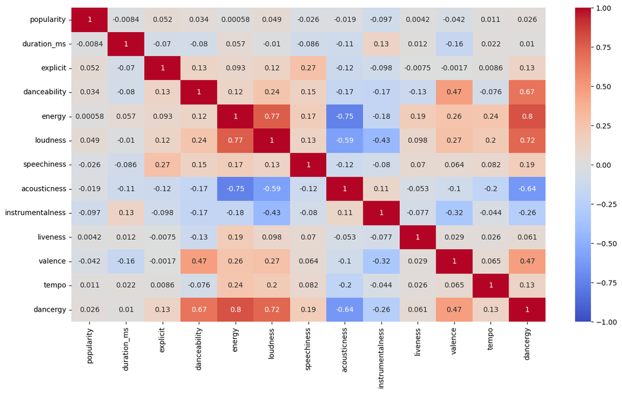

```python
plt.figure(figsize = (15, 8))
sns.heatmap(corr, annot = True, cmap = "coolwarm", vmin = -1)
print("possible correlations:")
plt.show()
```

Some notes about this diagram: As a whole, none of the categories have a strong relationship between themselves and popularity. However, note that some interesting relationships are that energy has a strong positive correlation to loudness and a strong negative relationship with acousticness. This is beneficial because it demonstrates several trends in the music industry. However, we didn't find a strong relationship between dancergy and popularity, but it is positive. This suggests that as dancergy increases, popularity increases. This could be due to the variety of genres. For example, a sad song might be popular, despite a lack of dancergy. Nonetheless, there is a positive correlation.

Looking at a scatter plot, can tell us more about each individual distribution. For example, while there are a lot of songs that aren't popular of all different danceability, it appears that there are more popular songs with higher dancergy. We will examine this more later on.

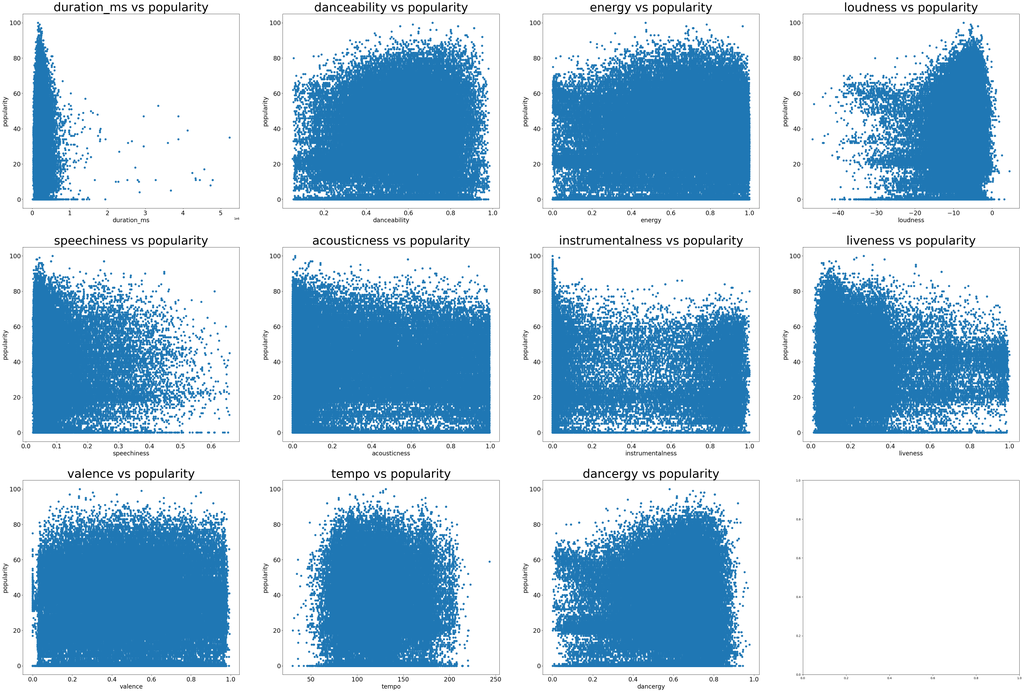

```python
def scatterplots(row, data):
  fig, ax = plt.subplots(3, 4, figsize= (60, 40))
  i = 0
  j = 0
  for col in data.columns:
    if (col != row and (col != "explicit") and (col != "genre") and (col != "text")):
      ax[i][j].scatter(data[col], data[row])
      ax[i][j].set_title(col + " vs " + row)
      ax[i][j].title.set_size(40)
      ax[i][j].tick_params(axis='x', which='both', labelsize=20)
      ax[i][j].tick_params(axis='y', which='both', labelsize=20)
      ax[i][j].set_xlabel(col, fontsize = 20)
      ax[i][j].set_ylabel(row, fontsize = 20)
      j = 0 if j == 3 else j + 1
      i = i + 1 if j == 0 else i
scatterplots("popularity", tracks)
```

### Focusing on Popularity and Dancergy

Simplified the DataFrame for the following analysis to only have columns for popularity and dancergy.

```python
filtered = pd.DataFrame()
filtered["Popularity"] = tracks["popularity"]
filtered["Dancergy"] = tracks["dancergy"]
filtered.head()
```

|  | Popularity | Dancergy |
| --- | --- | --- |
| 0 | 73 | 0.558244 |
| 1 | 55 | 0.264045 |
| 2 | 57 | 0.396538 |
| 3 | 71 | 0.125911 |
| 4 | 82 | 0.523234 |

```python
filtered[filtered["Popularity"] > 70].count()
```

```
Popularity    4831
Dancergy      4831
dtype: int64
```

Bootstrapping:

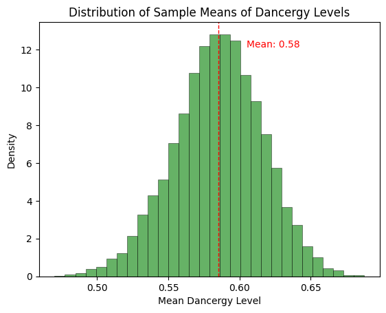

```python
sample_size = 30
num_samples = 10000

# Initialize array to store sample means
sample_means = np.zeros(num_samples)

# Draw samples and calculate means
for i in range(num_samples):
    sample = filtered['Dancergy'].sample(n=sample_size, replace=True)
    sample_means[i] = sample.mean()

# Plot
plt.hist(sample_means, bins=30, density=True, alpha=0.6, color='g', edgecolor='black', linewidth=0.5)
plt.title('Distribution of Sample Means of Dancergy Levels')
plt.xlabel('Mean Dancergy Level')
plt.ylabel('Density')

# Calculate mean of sample means
mean_of_sample_means = np.mean(sample_means)

# Add vertical line for the mean
plt.axvline(mean_of_sample_means, color='r', linestyle='dashed', linewidth=1)

# Annotate the mean
plt.text(mean_of_sample_means + 0.02, plt.ylim()[1]*0.9, f'Mean: {mean_of_sample_means:.2f}', color='r')

plt.show()
```

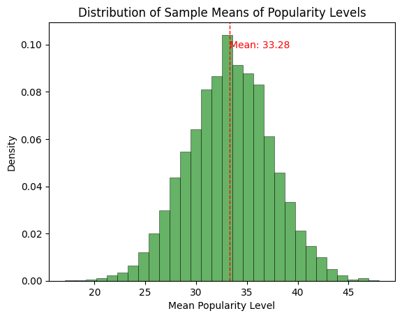

```python
filtered["Popularity"] = tracks["popularity"]

sample_size = 30
num_samples = 4000

# Initialize array to store sample means
sample_means = np.zeros(num_samples)

# Draw samples and calculate means
for i in range(num_samples):
    sample = filtered['Popularity'].sample(n=sample_size, replace=True)
    sample_means[i] = sample.mean()

# Plot histogram of sample means
plt.hist(sample_means, bins=30, density=True, alpha=0.6, color='g', edgecolor='black', linewidth=0.5)
plt.title('Distribution of Sample Means of Popularity Levels')
plt.xlabel('Mean Popularity Level')
plt.ylabel('Density')

# Calculate mean of sample means
mean_of_sample_means = np.mean(sample_means)

# Add vertical line for the mean
plt.axvline(mean_of_sample_means, color='r', linestyle='dashed', linewidth=1)

# Annotate the mean
plt.text(mean_of_sample_means + 0.02, plt.ylim()[1]*0.9, f'Mean: {mean_of_sample_means:.2f}', color='r')

plt.show()
```

```python
describe2 = tracks.describe()
mean = describe2["dancergy"]["mean"]
std = describe2["dancergy"]["std"]
std
```

```
0.16983839696462602
```

Shows that a majority of songs, aren't popular. The distribution of sample means show a mean popularity mean of around 30, well below the 60 required to be considered popular.

### A z-test to compare popularity of a sample of high dancergy songs vs population:

Null Hypothesis: The danceability and energy (danceability) of the song has no impact on the popularity of the song

Alternative Hypothesis: The danceability and energy (danceability) of the song increases the likelihood that the song is popular.

alpha: 0.05

```python
one_std_above = mean + std
filtered_high_dancergy = filtered[filtered['Dancergy'] >= one_std_above].head(30)

# Extract popularity levels into an array
popularity_array = filtered_high_dancergy['Popularity'].values

print(popularity_array)

# Method 1 : Using Z-score

sample_mean = np.mean(popularity_array)
sample_size = np.count_nonzero(popularity_array)
population_mean = describe2["popularity"]["mean"]
population_std = describe2["popularity"]["std"]
alpha = 0.05
z_score = (sample_mean-population_mean)/(population_std/math.sqrt(sample_size))
critical_value = 1.645 # from z table
print("Z SCORE: " + str(z_score))


if(z_score<critical_value):
    print('WE FAIL TO REJECT THE NULL HYPOTHESIS')
else:
    print('WE REJECT THE NULL HYPOTHESIS')
```

```
[56 62  0 20 33 58 32 29 50 67 28 28 65 27 26 47 26 26 42 39 38 38 44 37
 39 42 37 32 37 35]
Z SCORE: 1.121232967887784
WE FAIL TO REJECT THE NULL HYPOTHESIS
```

To conduct our right-tailed z-test, we pulled 30 songs that had a dancergy level greater than or equal to .76. This is what we would consider "high dancergy" because it is 1 standard deviation above the average. We took the mean of popularity scores among these 30 high dancergy songs and used that in our z-score calculations. Because we obtained a z-score of 1.12, we failed to reject our null hypothesis because it is less than our critical value of 1.645. !.646 is the corresponding critical value for our alpha level of .05. We cannot conclude that high dancergy levels are correlated positively to popularity.

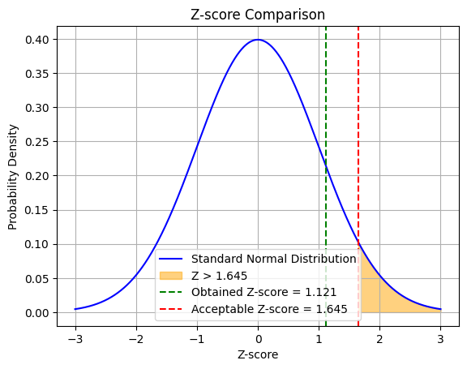

```python
# Range of z-scores
z_scores = np.linspace(-3, 3, 1000)

# Plot the standard normal distribution
plt.plot(z_scores, norm.pdf(z_scores, 0, 1), color='b', label='Standard Normal Distribution')

# Shade the area after z-score of 1.645
plt.fill_between(z_scores, norm.pdf(z_scores, 0, 1), where=(z_scores > 1.645), color='orange', alpha=0.5, label='Z > 1.645')

# Highlight the obtained z-score
obtained_z = 1.121
plt.axvline(x=obtained_z, color='g', linestyle='--', label=f'Obtained Z-score = {obtained_z}')

# Highlight the z-score of 1.645
acceptable_z = 1.645
plt.axvline(x=acceptable_z, color='r', linestyle='--', label=f'Acceptable Z-score = {acceptable_z}')

# Add labels and legend
plt.title('Z-score Comparison')
plt.xlabel('Z-score')
plt.ylabel('Probability Density')
plt.legend()

# Show plot
plt.grid(True)
plt.show()
```